## Reactivity

We’ve already seen some examples with our `render` functions, but what exactly is **reactivity**?

Reactivity is a 2-step process

1. **Reactive values** *notify* functions that use them when they become invalid
2. Objects created by **reactive functions** *respond*

## Some Reactive Functions

- render*() functions
- reactive()
- reactiveValues()
- eventReactive()
- observe()
- observeEvent()

## More Harry Potter Comparisons

The Knight Bus is our connection between regular R code (Muggle World) and the world of reactives (Wizarding World)

`knight_bus <- function(input, output, session) {` reactive code here! `}`

## 3 Types of KB Passengers

inputs

conductors

observers

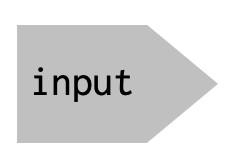

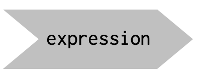

[figure not shown]

## Reactivity Diagram

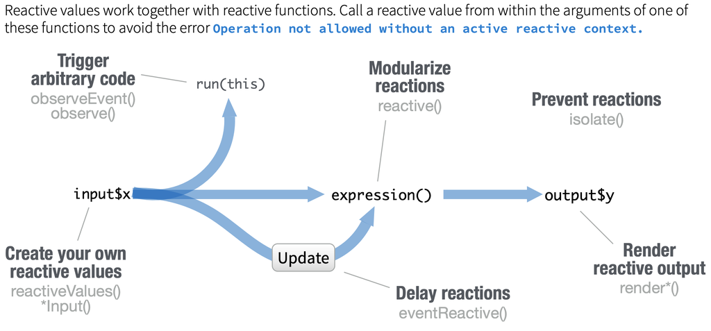

## Project 2: Pythagorean Theorem

- Run `pythagorean-1.R` and change the input values a few times.
- Stop the app
- Run `reactlogShow()` (may need to install first)

## Adding an expression: modularizing reactions

- Run `pythagorean-2.R` and change the input values.
- Stop the app
- Run `reactlogShow()`
- Reactives are lazy and only update when they need to

## Reactives vs. observers

**Reactives**: calculate or cache a value, meant to be used as a variable, has a result

**Observers**: runs some code when a dependency changes, doesn’t yield a result, isn’t used as input for other expressions, not assigned to a variable